# Math325FinalGradePredictor

Cody Overholt

12/4/2021

## Background

Math 325 is one of the major statistics classes offered at BYU-Idaho, as well as being some students first introduction to the R programming language. This class poses unique challenges by putting learning mathematical concepts alongside coding challenges. What can new Math 325 students do to maximize their chances of getting an A? The following analysis aims to answer that question.

The data for this exploration comes from the gradebooks of past Math 325 Students. Each final grade is categorized into two groups; those that got an “A” and those who got a different grade labelled as “Other”. All Information was anonymized to protect the individual’s privacy.

```r
datatable(train, extensions="Responsive", options=list(lengthMenu=c(3,5,10)))
```

|  | ID | FinalGrade | Project1 | Project2 | ProjectTotal | Analysis1 | Analysis2 | Analysis3 | Analysis4 | Analysis5 | Analysis6 | Analysis7 | Analysis8 | Analysis10 | Analysis11 | Analysis12 | Analysis13 | AnalysisTotal | IntroToCritiquing | Critique1 | Critique2 | Critique3 | Critique4 | Critique5 | Critique6 | Critique7 | Critique8 | Critiqhe10 | Critique11 | … |
| --- | --- | --- | --- | --- | --- | --- | --- | --- | --- | --- | --- | --- | --- | --- | --- | --- | --- | --- | --- | --- | --- | --- | --- | --- | --- | --- | --- | --- | --- | --- |
| 1 | 56 | Other | 7.5 | 0 | 7.5 | 2.416666667 | 1.541666667 | 2.416666667 | 2.25 | 2.25 | 1.25 | 2.5 | 2.5 | 1.583333333 | 1.666666667 | 1.791666667 | 0.75 | 22.91666667 | 0.769230769 | 0.769230769 | 0.769230769 | 0.769230769 | 0.769230769 | 0.769230769 | 0.769230769 | 0.769230769 | 0.769230769 | 0.769230769 | 0.769230769 | … |
| 2 | 60 | A | 7.5 | 7.5 | 15 | 2.727272727 | 2.727272727 | 2.727272727 | 2.727272727 | 2.727272727 | 2.727272727 | 2.727272727 | 2.5 | 2.636363636 | 2.727272727 | 2.727272727 |  | 29.68181818 | 0.833333333 | 0.833333333 | 0.833333333 | 0.833333333 | 0.833333333 | 0.833333333 | 0.833333333 | 0.833333333 | 0.833333333 | 0.833333333 | 0.833333333 | … |
| 3 | 217 | Other | 7.5 | 7.05 | 14.55 | 2.85 | 2.6 | 2.7 | 2.9 | 2.76 | 3 | 0.7 | 1.55 | 2.95 | 2.55 |  |  | 24.56 | 0.909090909 | 0.909090909 | 0.909090909 | 0.909090909 | 0.909090909 | 0.909090909 | 0.909090909 | 0.909090909 | 0.909090909 | 0.909090909 | 0.909090909 | … |
| 4 | 267 | Other | 0 | 0 | 0 | 2.166666667 | 0 | 0 | 0 | 0 | 1.625 | 2 | 1.041666667 | 1.791666667 | 0 | 0 | 2.5 | 11.125 | 0.769230769 | 0.769230769 | 0 | 0 | 0 | 0 | 0.769230769 | 0.769230769 | 0.769230769 | 0.769230769 | 0 | … |
| 5 | 373 | A | 7.5 | 7 | 14.5 | 2.727272727 | 2.727272727 | 2.727272727 | 2.727272727 | 2.727272727 | 2.727272727 | 2.727272727 | 2.5 | 2.545454546 | 2.727272727 | 2.727272727 |  | 29.59090909 | 0.833333333 | 0.833333333 | 0.833333333 | 0.833333333 | 0.833333333 | 0.833333333 | 0.833333333 | 0.833333333 | 0.833333333 | 0.833333333 | 0.833333333 | … |
| 6 | 398 | A | 7.5 | 7.5 | 15 | 2.727272727 | 2.727272727 | 2.727272727 | 2.727272727 | 2.454545455 | 2.727272727 | 2.227272727 | 1.727272727 | 2.545454546 | 2.545454546 | 2.090909091 |  | 27.22727273 | 0.833333333 | 0.833333333 | 0.833333333 | 0.833333333 | 0.833333333 | 0.833333333 | 0.833333333 | 0.833333333 | 0.833333333 | 0.833333333 | 0.833333333 | … |
| 7 | 430 | A | 7.5 | 7.5 | 15 | 2.416666667 | 2.5 | 2.5 | 2.25 | 2.5 | 2.5 | 2.5 | 2.333333333 | 2.5 | 2.5 | 2.5 | 2.5 | 29.5 | 0.769230769 | 0.769230769 | 0.769230769 | 0.769230769 | 0.769230769 | 0.769230769 | 0.769230769 | 0.769230769 | 0.769230769 | 0.769230769 | 0.769230769 | … |
| 8 | 500 | Other | 7.5 | 7.5 | 15 | 2.5 | 2.5 | 2.5 | 2.25 | 2.5 | 2.25 | 2.5 | 2.5 | 2.5 | 2.25 | 2.5 | 2.5 | 29.25 | 0.769230769 | 0.769230769 | 0.769230769 | 0.769230769 | 0.769230769 | 0.769230769 | 0.769230769 | 0.692307692 | 0.769230769 | 0.769230769 | 0.769230769 | … |
| 9 | 526 | Other | 7.5 | 7.5 | 15 | 1.681818182 | 2.727272727 | 2.727272727 | 2.727272727 | 2.727272727 | 2.727272727 | 0 | 2.727272727 | 0 | 2.727272727 | 2.727272727 |  | 23.5 | 0 | 0.833333333 | 0.833333333 | 0.833333333 | 0.833333333 | 0.833333333 | 0.833333333 | 0 | 0.833333333 | 0 | 0.833333333 | … |
| 10 | 639 | A | 7.5 | 6.75 | 14.25 | 2.727272727 | 2.727272727 | 2.727272727 | 2.727272727 | 2.727272727 | 2.636363636 | 2.727272727 | 2.681818182 | 2.727272727 | 2.727272727 | 2.727272727 |  | 29.86363636 | 0.833333333 | 0.833333333 | 0.833333333 | 0.833333333 | 0.833333333 | 0.833333333 | 0.833333333 | 0.833333333 | 0.833333333 | 0.833333333 | 0.833333333 | … |

[output cut: 110 more lines]

## Odds vs Probability

One important distinction that needs to be made before continuing is the difference between probability and odds. Probability tells you how many times an event will have a desired outcome out of the total number of events that occurred.

$$\text{Number of Favorable events (X)} \div \text{Number of Total events (N)}$$

The Odds of something happening are shown by telling you how many times an event does happen over the amount of times the event didn’t happen. By taking the log of the odds, it can be displayed as a percent. Using a logistic regression model, we can estimate the odds of an event happening given a set of known factors.

$$\text{Number of Favorable events (X)} \div \text{Number of Total events (X) - Number of Favorable events (N)}$$

## Important Factors of Success

The Mathematical Model used for this analysis is as follows:
$$P(Y_i = 1|\, x_i) = \frac{e^{\beta_0 + \beta_1 x_{i1} + \beta_2 x_{i2} + \beta_3 x_{i3}}}{1+e^{\beta_0 + \beta_1 x_{i1} + \beta_2 x_{i2} + \beta_3 x_{i3}}} \text{ Where } \beta_1 = \text{Avearage Analysis score}, \beta_2 = \text{Final Exam Score}, \beta_3 = \text{Class Activity Score}$$

The formula calculates the Odds of getting an “A” in the class.

$$\frac{e^{-67.54 + 1.43 x_{i1} + 0.552 x_{i2} + 4.55 x_{i3}}}{1+e^{-67.54 + 1.43 x_{i1} + 0.552 x_{i2} + 4.55 x_{i3}}}$$

When tested, this model was able to calculate the odds of getting an A with 92.5% accuracy assuming the calculated odds of getting an A were above 80%. At base the odds of getting an A in the class if you do no analyses, get a 0 on the final, and don’t do the class activities is effectively zero.

#### Class Activities

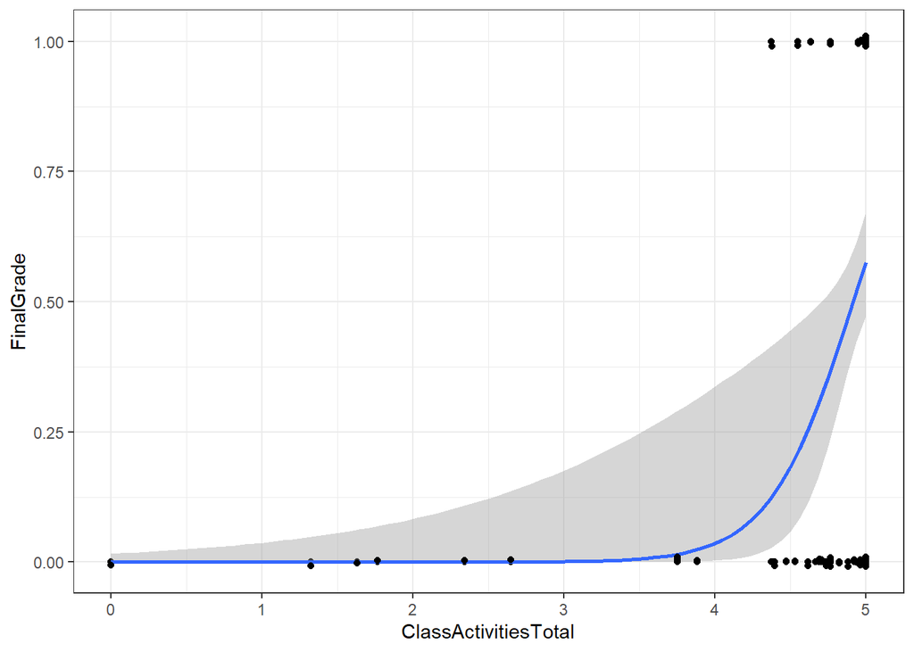

```r
train1 %>%
  ggplot(aes(x=ClassActivitiesTotal,y=FinalGrade))+
  geom_point()+
  geom_smooth(method = "glm",
              method.args = list(family="binomial"), formula = y~x)+
  geom_jitter(height = .01)+
  theme_bw()
```

#### Total Analysis Grades

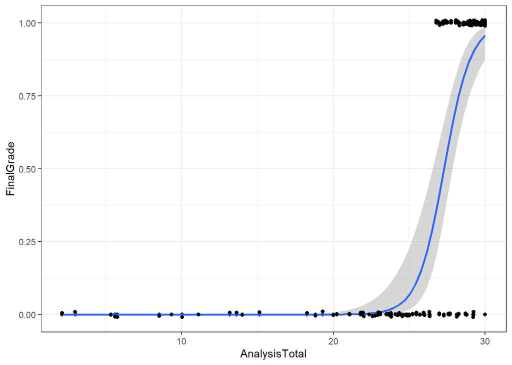

```r
#plots the analysis total against final grade
train1 %>%
  ggplot(aes(x=AnalysisTotal,y=FinalGrade))+
  geom_point()+
  geom_smooth(method = "glm",
              method.args = list(family="binomial"), formula = y~x)+
  geom_jitter(height = .01)+
  theme_bw()
```

#### Final Exam Grade

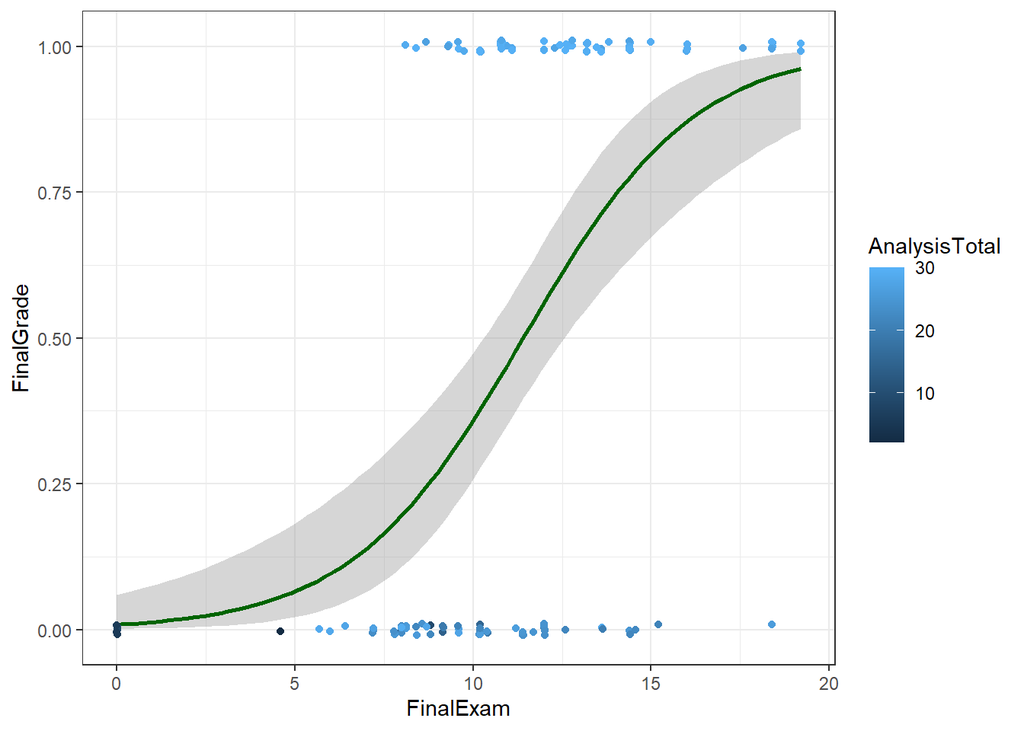

```r
train1 %>%
  ggplot(aes(color =AnalysisTotal,y=FinalGrade,  x=FinalExam))+
  geom_smooth(method = "glm",
              method.args = list(family="binomial"), formula = y~x, color = "darkgreen")+
  geom_jitter(height = .01)+
  theme_bw()
```

## Conclusion

In order to maximize your odds of getting an A in the class, do these three things: Attend Class and participate Resubmit every analysis to maximize points on revisions Study for the final exam

## Model Summary

The following describes the technical details of the model used.

```r
#model summary
summary(myglm) %>% pander()
```

|  | Estimate | Std. Error | z value | Pr(>\|z\|) |
| --- | --- | --- | --- | --- |
| **(Intercept)** | -67.54 | 16.15 | -4.182 | 2.89e-05 |
| **AnalysisTotal** | 1.43 | 0.3492 | 4.095 | 4.213e-05 |
| **FinalExam** | 0.553 | 0.1729 | 3.198 | 0.001384 |
| **ClassActivitiesTotal** | 4.551 | 1.936 | 2.351 | 0.01875 |

(Dispersion parameter for binomial family taken to be 1 )

| Null deviance: | 166.06 on 119 degrees of freedom |
| --- | --- |
| Residual deviance: | 36.68 on 116 degrees of freedom |

Hypothesis test

```r
#hoslen test
(hoslem.test(myglm$y, myglm$fitted.values)) %>% pander()
```

Hosmer and Lemeshow goodness of fit (GOF) test: `myglm$y, myglm$fitted.values`

| Test statistic | df | P value |
| --- | --- | --- |
| 1.277 | 8 | 0.9958 |

Validated Results

```r
table(myPreds > .8, my_test$FinalGrade) %>% pander()
```

|  | 0 | 1 |
| --- | --- | --- |
| **FALSE** | 19 | 2 |
| **TRUE** | 1 | 18 |